# PA1_template.Rmd

Leon Lu

10 August 2017

# Reproducible Research Week 2 Assignment - Course project1

It is now possible to collect a large amount of data about personal movement using activity monitoring devices such as a Fitbit, Nike Fuelband, or Jawbone Up. These type of devices are part of the “quantified self” movement – a group of enthusiasts who take measurements about themselves regularly to improve their health, to find patterns in their behavior, or because they are tech geeks. But these data remain under-utilized both because the raw data are hard to obtain and there is a lack of statistical methods and software for processing and interpreting the data.

This assignment makes use of data from a personal activity monitoring device. This device collects data at 5 minute intervals through out the day. The data consists of two months of data from an anonymous individual collected during the months of October and November, 2012 and include the number of steps taken in 5 minute intervals each day.

## 1. Code for reading in the dataset and/or processing the data

### Load libraries

```r
library(ggplot2)
library(scales)
library(lubridate)
library(lattice)
```

### Load Data

Set working directory

```r
setwd("D:\\Liang\\Workspace\\DataScience\\C5\\W2")
```

Download data if file doesn’t exist and read data from file activity.csv to variable Act

```r
if ( !file.exists("activity.csv") )
{
  file_url = "https://d396qusza40orc.cloudfront.net/repdata%2Fdata%2Factivity.zip"
  download.file(file_url, destfile="activity.zip")
  unzip("activity.zip", overwrite = TRUE)
}

Act <- read.csv("activity.csv")
```

## 2. Histogram of the total number of steps taken each day

### Data Processing

Summarize the total steps by date

```r
Total_Steps_Day <- aggregate(steps ~ date, Act, sum)
```

### Including Plots

Generate Histogram plot of the total number of steps taken each day of Year 2012

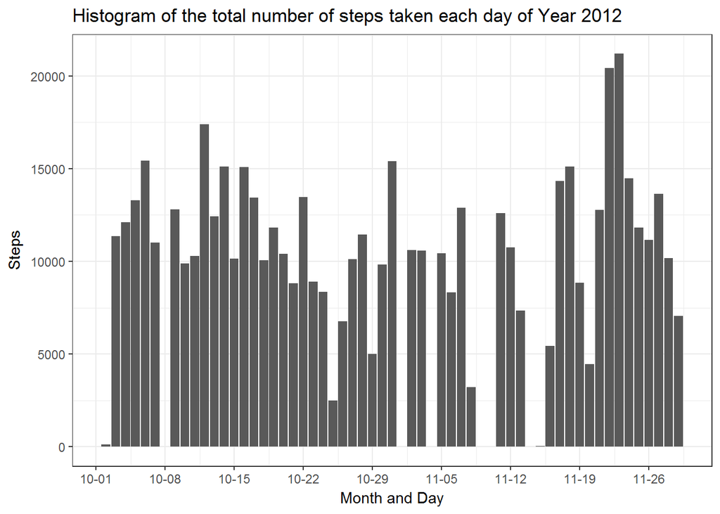

```r
g <- ggplot(Total_Steps_Day, aes(as.Date(date, '%Y-%m-%d'))) + geom_histogram(aes(weight=steps), stat = "count")
g <- g + scale_x_date(labels=date_format("%m-%d"), date_breaks = "1 weeks")
g <- g + labs(title="Histogram of the total number of steps taken each day of Year 2012", x="Month and Day", y="Steps") + theme_bw()
print(g)
```

### Data Processing

```r
Mean_Total_Steps <- mean(Total_Steps_Day$steps)

Median_Total_Steps <-median(Total_Steps_Day$steps)
```

## 4. Time series plot of the average number of steps taken & 5.The 5-minute interval that, on average, contains the maximum number of steps

### Data Processing

```r
Avg_Steps_5mins <- aggregate(steps ~ interval, Act, mean)
Max_Steps_interval <- subset(Avg_Steps_5mins, steps == max(Avg_Steps_5mins$steps))
Max_Steps_interval
```

```
##     interval    steps
## 104      835 206.1698
```

### Including Plots

Plot average daily activity in 5 mins interval and show the interval with maximum number of steps of 5 mins interval on average

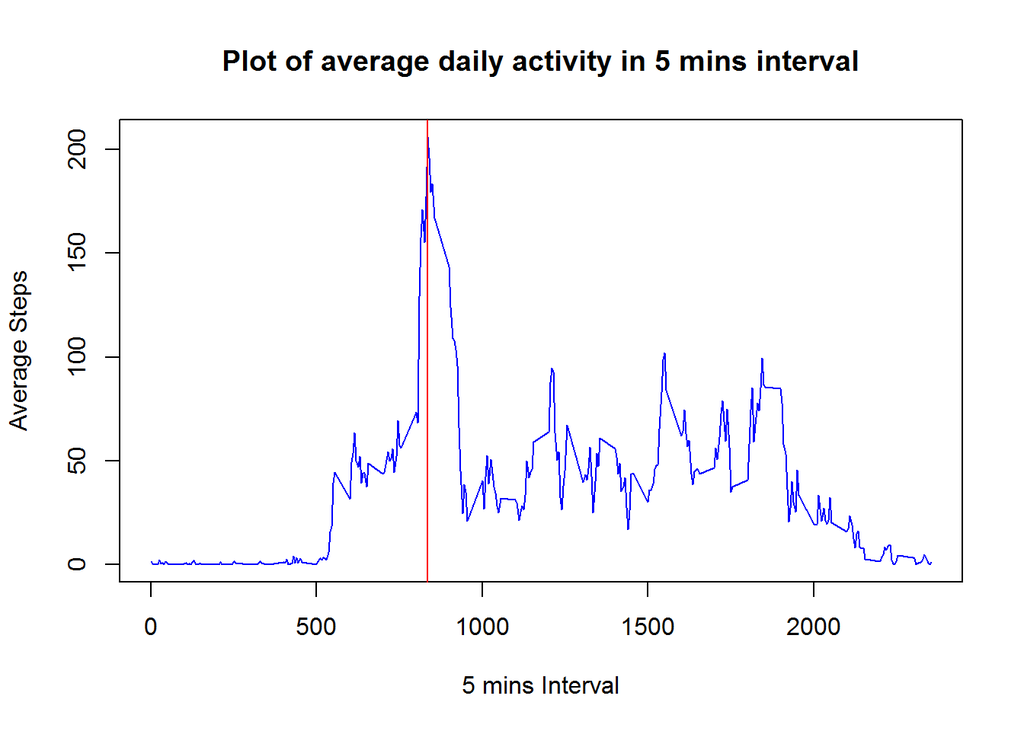

```r
with(Avg_Steps_5mins, plot(interval, steps, type="l", pch=19, col="blue", main="Plot of average daily activity in 5 mins interval", xlab="5 mins Interval", ylab="Average Steps"))
abline(v=Max_Steps_interval$interval, col="red")
```

## 6. Code to describe and show a strategy for imputing missing data

### Imputing missing values

Calculate and report the total number of missing values in the dataset (i.e. the total number of rows with NAs)

```r
sum(is.na(Act$steps))
```

```
## [1] 2304
```

There are 2304 records missing value

Devise a strategy for filling in all of the missing values in the dataset. Replace the missing value with the mean for that 5-minute interval, and creat a new dataset that is equal to the original dataset but with the missing data filled in.

```r
Act_noNA <- Act
for (i in 1:nrow(Act_noNA)) {
  if ( is.na(Act_noNA$steps[i])) {
    Act_noNA$steps[i] <- Avg_Steps_5mins[which(Act_noNA$interval[i] == Avg_Steps_5mins$interval), ]$steps
  }
}
Act_noNA[! complete.cases(Act_noNA$steps),]
```

```
## [1] steps    date     interval
## <0 rows> (or 0-length row.names)
```